# Stat_VR

## 5.3 Сглаживание временного ряда и выделение тренда

Здесь можно ощутить разницу между сглаживанием и выделением тренда. Сглаживание - сгладить ряд, то есть снять случайные колебания. За счет того, что в сглаживаниив том или ином виде участвует усреднение, то противоположные колебания обращаются в ноль. Если мы выберем маленькую ширину окна, то будем наблюдать именно этот результат - сглаживание мелких колебаний.  
Если выберем большую ширину окна, то сглаживание будет сильным, в итоге получится в чистом виде среднее значение изменения ряда - это и есть тренд.  
Вопрос: что делать с отсутствием части ряда в начале и в конце графика - “хвостов” при сглаживании? (Сглаживании, как я поняла, также подразумевает наличие хвостов.)  
Для этого вместо “хвостов” можно например взять реальные данные или использовать на “Хвостах” фильтр с меньшей длиной окна. Попробуем второй вариант. Для этого в функции filter установим circular=TRUE.

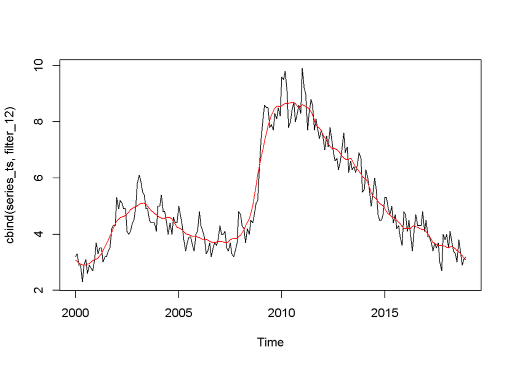

```r
filt <- c(1/24, rep(1/12, 11), 1/24)
filter_12<-filter(series_ts,filt,method="convolution",sides=2,circular=TRUE)
plot.ts(cbind(series_ts,filter_12), plot.type = "single",col=c("black","red"))
```

Сделаем окно побольше чтобы явно убедится, что хвосты “заполнены”.Нарисуем красной линеей с хвостами, а зеленой без хвостов.

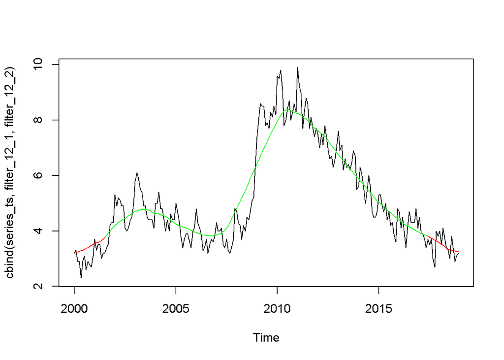

```r
filt <- c(1/72, rep(1/36, 35), 1/72)
filter_12_1<-filter(series_ts,filt,method="convolution",sides=2,circular = TRUE)
filter_12_2<-filter(series_ts,filt,method="convolution",sides=2)
plot.ts(cbind(series_ts,filter_12_1,filter_12_2), plot.type = "single",col=c("black","red","green"))
```

## 5.4 Проверка

Надо бы проверить, можно ли использовать circular для таких целей. Можно взять ряд, у которого значения слева сильно отличаются от значений с правой стороны и посмотреть на осмысленность результата (вдруг эта опция соответствует тому, что когда заканчиваются значения справа, они дополняются значениями слева, как бы по кругу).

```r
#data("AustralianWine")
#wine <- window(AustralianWine, end = time(AustralianWine)[120])
#fort <- ts(wine[, "Red"],frequency = 12)
filt <- c(1/24, rep(1/12, 11), 1/24)

#filter_fort_1<-filter(fort,filt,method="convolution",sides=2,circular=TRUE)
#filter_fort_2<-filter(fort,filt,method="convolution",sides=2)
#plot.ts(cbind(fort,filter_fort_1,filter_fort_2), plot.type = "single",col=c("black","red","green"))
```

```r
MoveA_plot <- function(x, n) {
  new_x <- x
  s<- rep(0, length(x))
  count <- rep(0, length(x))+ !is.na(new_x)
  new_x[is.na(new_x)] <- 0
  s <- s + new_x
      for (i in 1:(n/2)){
            new_x   <- c(rep(NA, i), x[1:(length(x)-i)])
            count <- count + !is.na(new_x)
            new_x[is.na(new_x)] <- 0
            s <- s + new_x
      }
      for (i in 1: (n/2)) {
            new_x   <- c(x[(i+1):length(x)], rep(NA, i))
            count <- count + !is.na(new_x)
            new_x[is.na(new_x)] <- 0
            s <- s + new_x
      }
  plot(x)
  lines(s/count,col="red")
}
#MoveA_plot(fort,12)
```

## 5.5 Периодограмма остатка после выделения тренда.

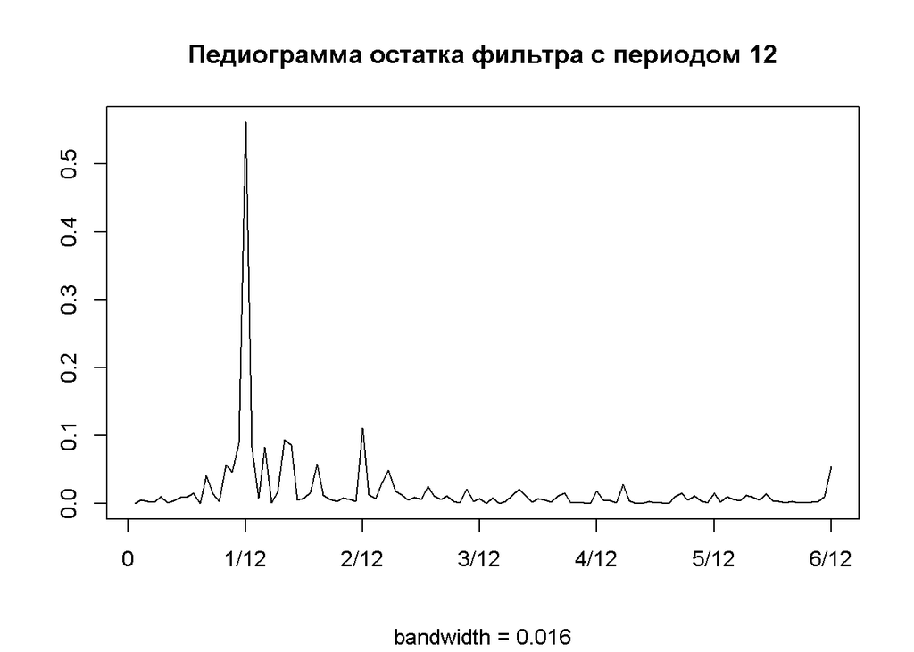

```r
#remainder
filter_MA_R<-function(x,w)
{
  res<-stats::filter(x,c(1/(2*w),rep(1/w,w-1),1/(2*w)),method="convolution",sides=2)
  return(na.omit(x-res))
}

ost_12<-filter_MA_R(series_ts,12)

spec.pgram(ost_12,log="no",detrend=TRUE,xaxt='n',fast =TRUE,main="Педиограмма остатка фильтра с периодом 12",ann="False")
axis(1, at = c(0,1,2,3,4,5,6), labels = c('0', '1/12', '2/12', '3/12', '4/12', '5/12', '6/12'))
```

Понятие тренда относительное, но если есть периодичность, то тренд должен меняться медленнее чем период. Другими словами тренд должен лежать левее 1/12. То есть в остатке тренда нет.  
Но видим небольшой скачок на 6/12, 2/12 - есть cos с периодом 2, 6 и 12.

Помним, что если автокорреляция остатка напоминает белый шум, значит сигнал выделили хорошо.

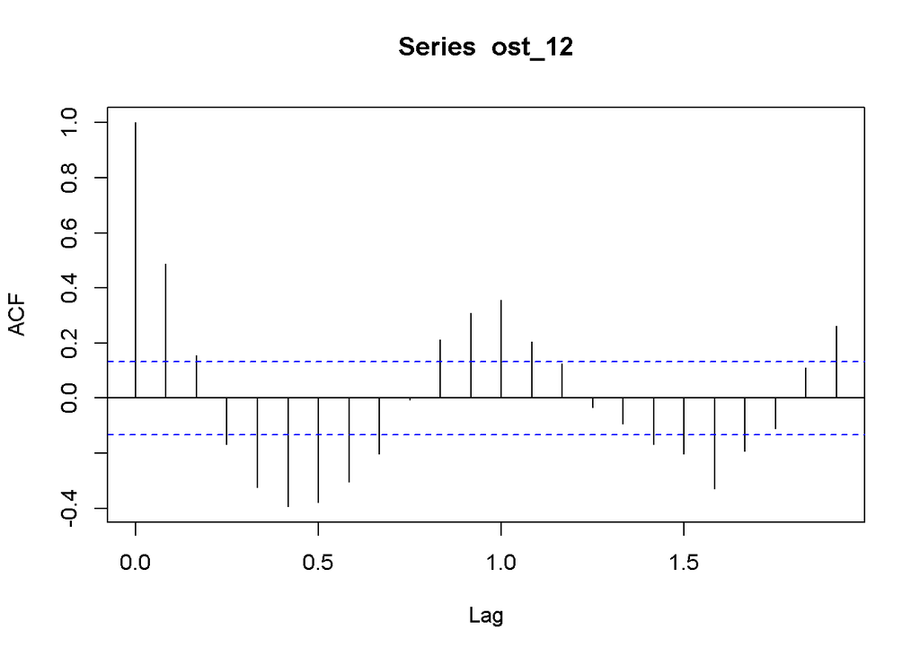

```r
acf(ost_12)
```

Видим, что периодичность осатлась, но так как мы хотели выделить тренд, то все хорошо.

# 6 Амплитудно-частотная характеристика фильтра (АЧХ).

$$H_{\phi}(z)=\sum_{i}h_iz^{-i} \text{-передаточная функция},\text{ возьмем } z=\exp{(i2\pi w)}, A_{\phi}(w)=|H_{\phi}(e^{i2\pi w})| \text{ - амплитудно-частотная характеристика (АЧХ)}$$
Рассмотрим АЧХ фильтра, воспользуемся написанной Н. Э. Голяндиной функцию.

```r
afc <- function(filter, omega) {
k <- seq_along(filter) - 1
h <- function(o) sum(rev(filter) * exp(-k*1i * o))
abs(sapply(omega, h))
}
```

## 6.1 Разность соседних точек

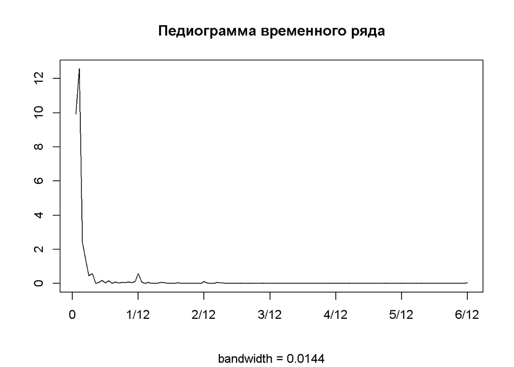

```r
diff<-function(row){
  n<-length(row)
  new_row<-rep(NA,n-1)
  for (i in 2:n){
    new_row[i-1]<-row[i]-row[i-1]
  }
    return(new_row)
}

spec.pgram(series_ts,log="no",detrend=TRUE,xaxt='n',fast =TRUE,main="Педиограмма временного ряда",ann="False")
axis(1, at = c(0,1,2,3,4,5,6), labels = c('0', '1/12', '2/12', '3/12', '4/12', '5/12', '6/12'))
```

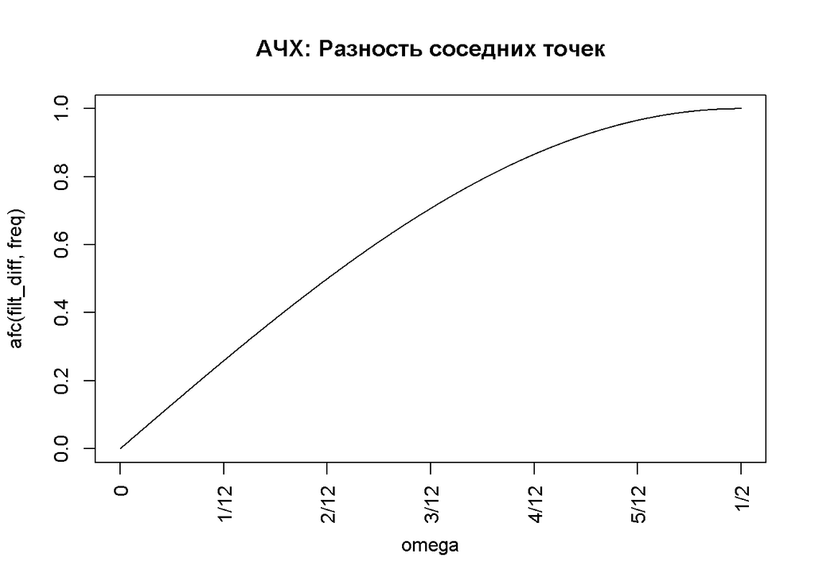

```r
freq <- seq(0, pi, 0.001)
filt_diff <- c(1/2,-1/2)
omega <- freq/2/pi
plot(afc(filt_diff, freq) ~ omega, type = "l",xaxt="n",main="АЧХ: Разность соседних точек")
axis(1, at = c( 0,1/12, 2/12, 3/12, 4/12, 5/12,1/2),
     labels = c("0","1/12", "2/12", "3/12", "4/12", "5/12","1/2"), las = 2)
```

По АЧХ видно, что данный фильтр подавляет низкие частоты и увеличивает высокие, другими словами выделяет шум.

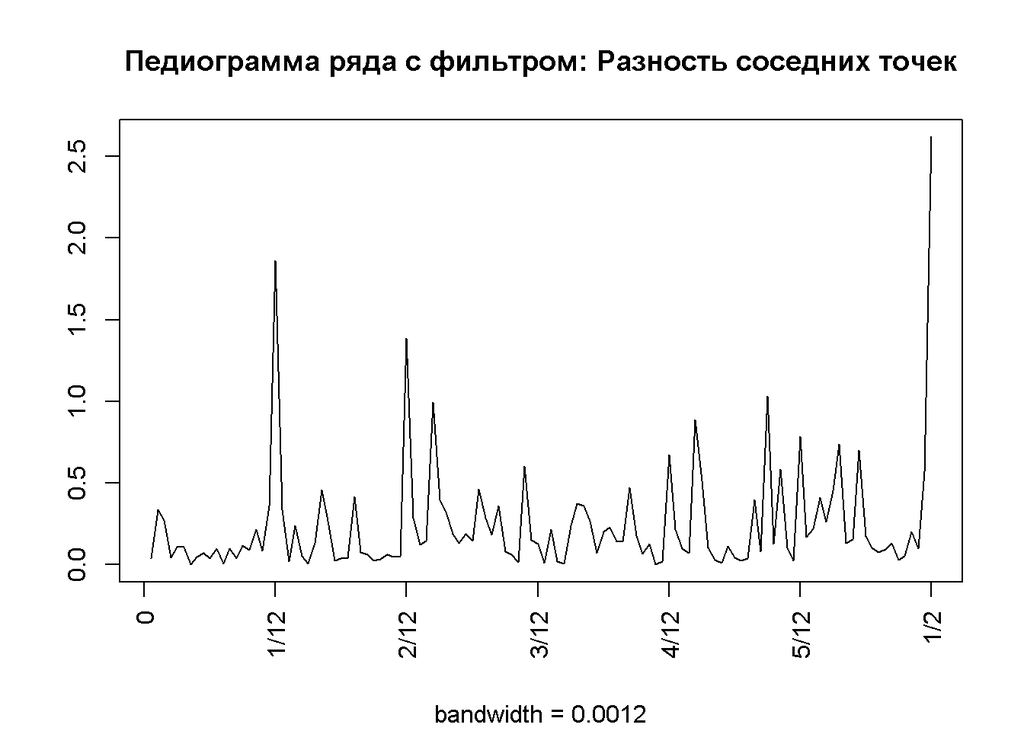

```r
spec.pgram(diff(series_ts),log="no",detrend=TRUE,xaxt='n',fast =TRUE,main="Педиограмма ряда с фильтром: Разность соседних точек",ann="False")
axis(1, at = c( 0,1/12, 2/12, 3/12, 4/12, 5/12,1/2),
     labels = c("0","1/12", "2/12", "3/12", "4/12", "5/12","1/2"), las = 2)
```

## 6.2 Cумма соседних точек

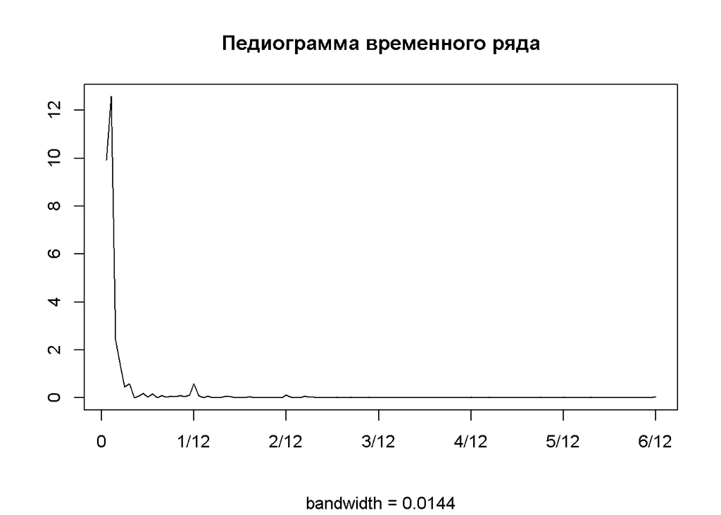

```r
sum<-function(row){
  n<-length(row)
  new_row<-rep(NA,n-1)
  for (i in 2:n){
    new_row[i-1]<-row[i]+row[i-1]
  }
    return(new_row)
}


spec.pgram(series_ts,log="no",detrend=TRUE,xaxt='n',fast =TRUE,main="Педиограмма временного ряда",ann="False")
axis(1, at = c(0,1,2,3,4,5,6), labels = c('0', '1/12', '2/12', '3/12', '4/12', '5/12', '6/12'))
```

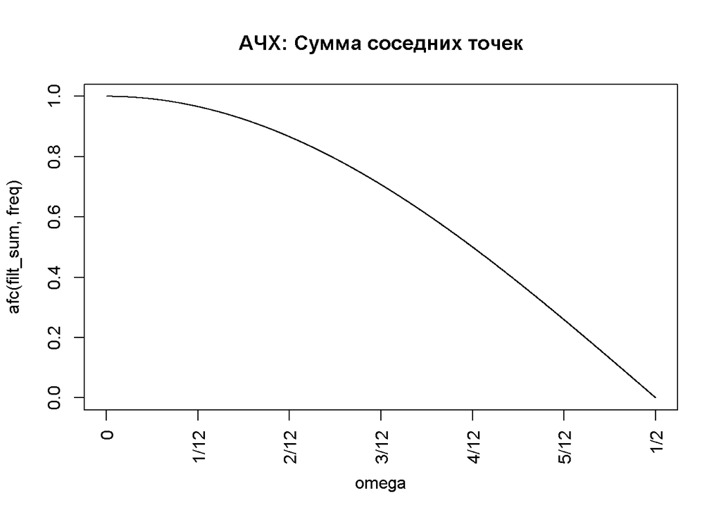

```r
freq <- seq(0, pi, 0.001)
filt_sum <- c(1/2,1/2)

omega <- freq/2/pi
plot(afc(filt_sum, freq) ~ omega, type = "l",xaxt="n",main="АЧХ: Cумма соседних точек")
axis(1, at = c( 0,1/12, 2/12, 3/12, 4/12, 5/12,1/2),
     labels = c("0","1/12", "2/12", "3/12", "4/12", "5/12","1/2"), las = 2)
```

По АЧХ видно, что данный фильтр увеличивает низкие частоты и уменьшает высокие, другими словами выделяет тренд.

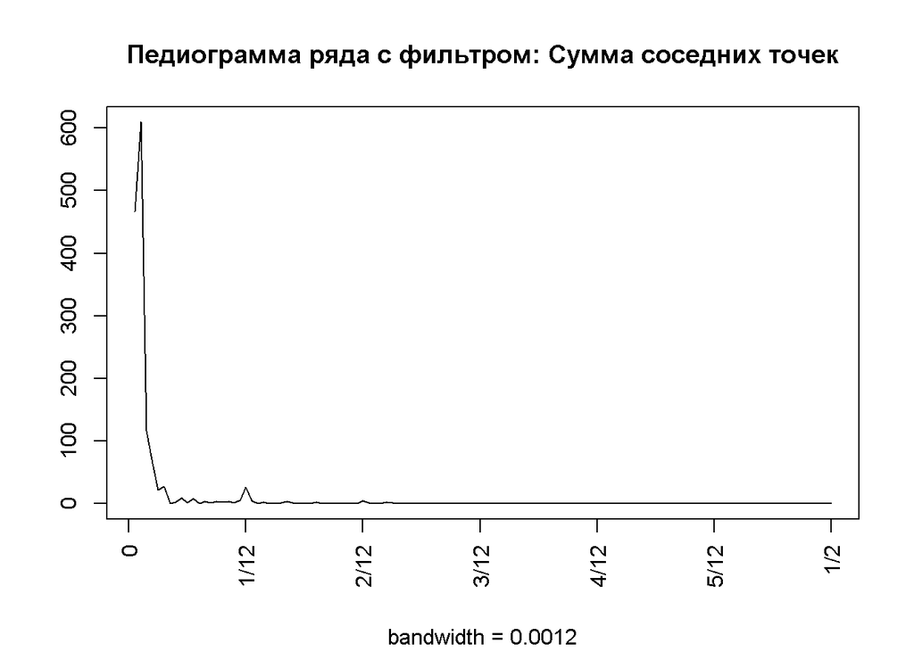

```r
spec.pgram(sum(series_ts),log="no",detrend=TRUE,xaxt='n',fast =TRUE,main="Педиограмма ряда с фильтром: Cумма соседних точек",ann="False")
axis(1, at = c( 0,1/12, 2/12, 3/12, 4/12, 5/12,1/2), labels = c("0","1/12", "2/12", "3/12", "4/12", "5/12","1/2"), las = 2)
```

# 7 Выделение тренда с помощью параметрической регрессии

## 7.1 Линейная регрессия

Убедимся, что линейная регрессия нам не подходит для выделения нелинейного тренда.

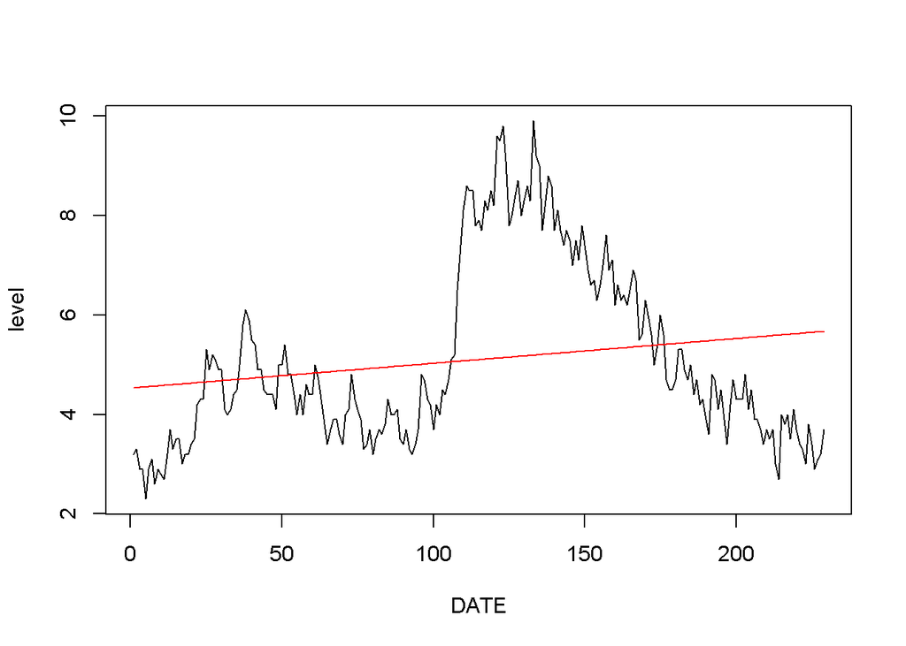

```r
series[,1]<-as.double(series[,1])
regres<-function(i){
reg<-  lm(series[,2] ~ poly(series[,1],i),data=series)
plot(series,type="l")
lines(reg$fitted.values, col='red')
}
regres(1)
```

## 7.2 Полиномиальная регрессия

(не подходит для прогнозирования)  
Квадратичная тоже плохо приближает.

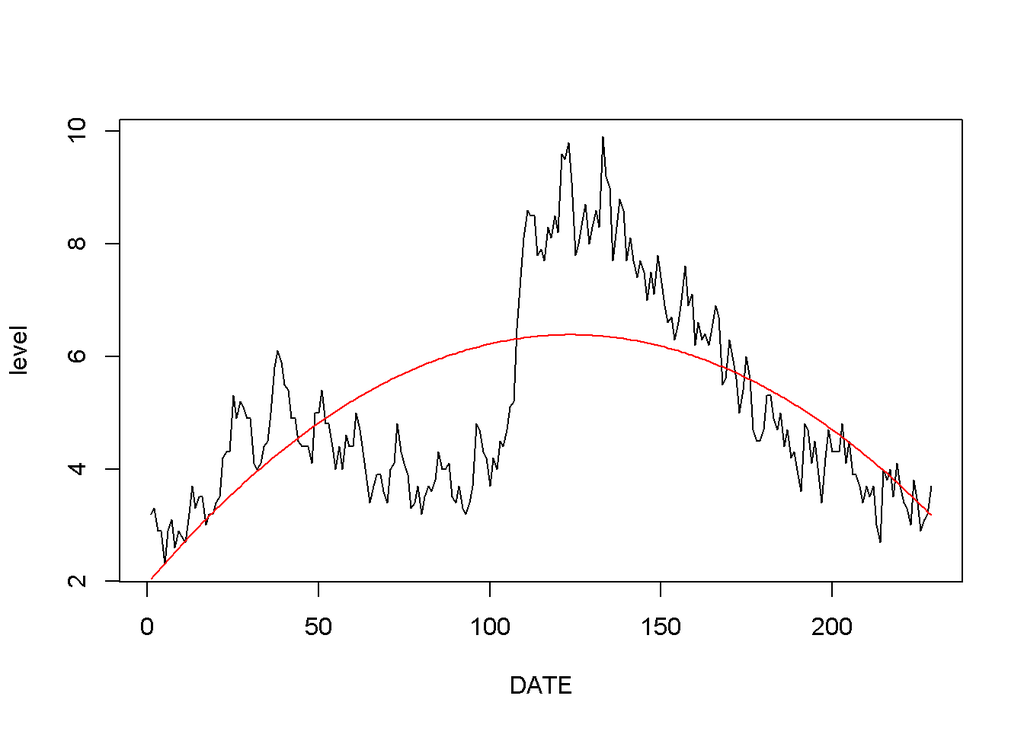

```r
regres(2)
```

Давайте сразу замахнемся на высокую степень полинома, например 12.

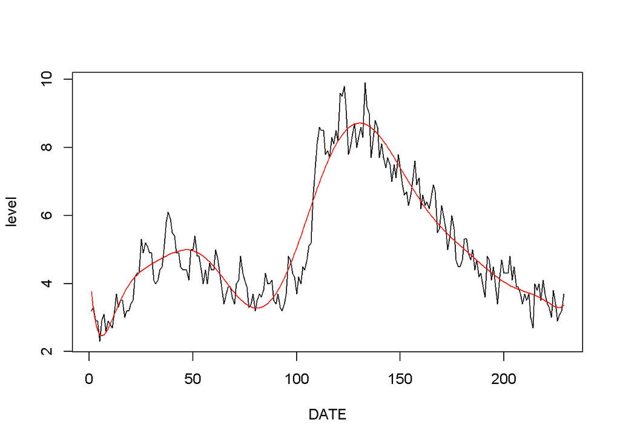

```r
regres(12)
```

Уже более похоже на тренд.

# 8 Растекание частоты в периодограмме.

Пример
$$x_n=A\cos(2\pi w n+\phi),n=1:N$$
$w=\frac{k}{N}$ - означает попадание в решетку
$w \not=\frac{k}{N}$ - не попадает в решетку, $\cos$ не ортогонален ни одному вектору из базиса - РАСТЕКАНИЕ ЧАСТОТЫ (когда частоты не попадают в решетку)
Приведем периодограмму наглядного примера растекания частоты.

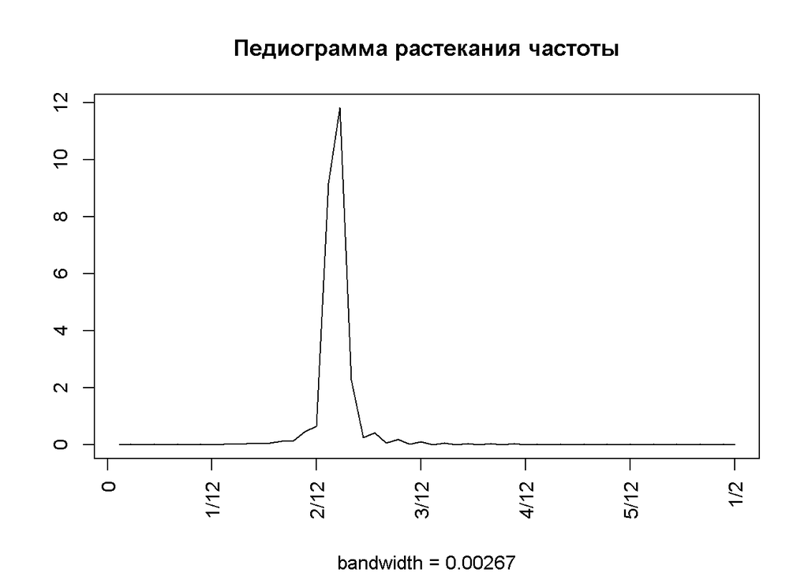

```r
spec.pgram(cos(2*pi*1:54*2/11),  log='no',detrend = FALSE, fast = FALSE,taper=0, pad=TRUE,main="Педиограмма растекания частоты",ann="False",xaxt='n')

axis(1, at = c( 0,1/12, 2/12, 3/12, 4/12, 5/12,1/2),
     labels = c("0","1/12", "2/12", "3/12", "4/12", "5/12","1/2"), las = 2)
```

## 8.1 Подправка длины ряда для ее устранения.

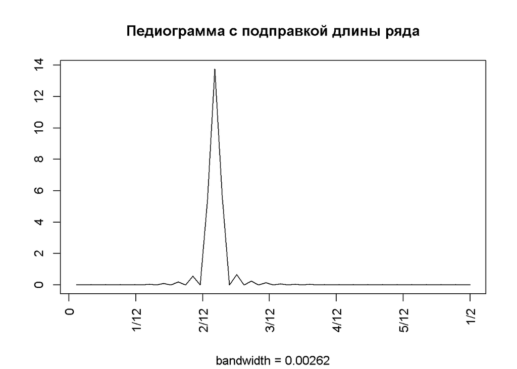

```r
x<-c(1:54,0)
spec.pgram(cos(2*pi*x*2/11),  log='no',detrend = FALSE, fast = FALSE, main="Педиограмма с подправкой длины ряда",ann="False",xaxt='n', taper=0,pad=TRUE)
axis(1, at = c( 0,1/12, 2/12, 3/12, 4/12, 5/12,1/2),
     labels = c("0","1/12", "2/12", "3/12", "4/12", "5/12","1/2"), las = 2)
```

Видим, что растекания нет.

# 9 Аддитивная и мультипликативная модели данных

### 9.0.1 Аддитивная модель

$$X_n=T_n+C_n+E_n$$
где $T_n$ - тренд, $C_n$ - постоянная амплитуда, $E_n$ - постоянная дисперсия шума.

### 9.0.2 мультипликативная модель

$$X_n=T_n(1+C_n)(1+E_n)=T_n+T_nC_n+T_n(1+C_n)E_n$$
$T_n$- тренд, $T_nC_n$-амплитуда колебаний ведет себя пропорционально тренду, $T_n(1+C_n)E_n$ - Шум пропорционален всему сигналу(шуму с колебанием).

### 9.0.3 Преобразования для стабилизации дисперсии

1.мультипликативная модель - $\ln(X)$  
2.пуассоновский шум - $\sqrt{X}$  
3.данные имеют вид от 0 до 1 (типо вероятности) и зависимость $\sigma(X)=\sqrt{X(1-X)}$ - $\arcsin{X}$

Давайте рассмотрим наш ряд

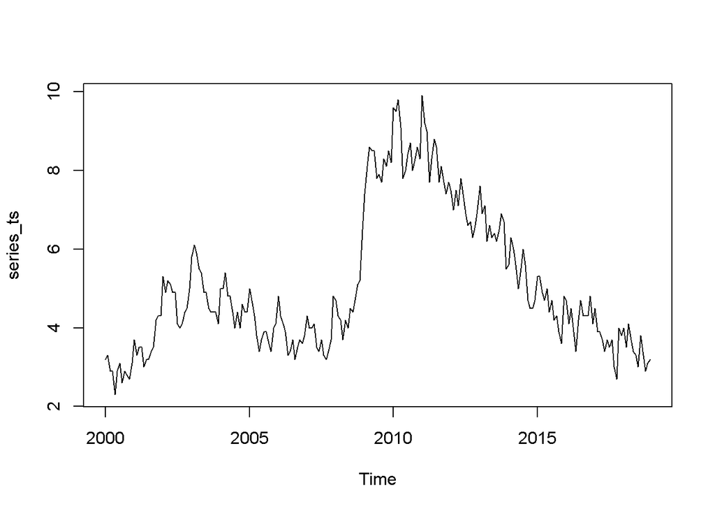

```r
plot.ts(series_ts)
```

Предполагаю, что модель аддитивная, так как размер амплитуды/шума постоянны по всему ряду(не ведет себя пропорционально тренду + шум не пропорционален всему сигналу).

# 10 Скользящая медиана

(Сравним скоььзящее среднее и скользящую медиану) Среднее арифметическое очень зависит от аутлайнеров. Скользящая медиана решает проблему выбросов, так как является устойчивой, робастой оценкой, но при этом график скользящей медианы не будет гладкой кривой. Также она не является оценкой математического ожидания, если распределение несимметричное.

```r
med <- runmed(series_ts, 12)
```

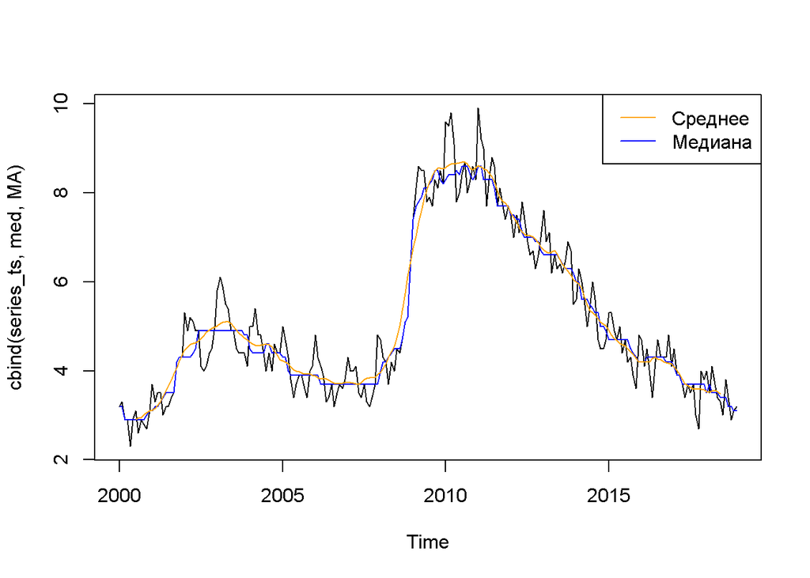

```r
filt <- c(1/24, rep(1/12, 11), 1/24)
MA<-filter(series_ts,filt,method="convolution",sides=2)
plot.ts(cbind(series_ts,med,MA), plot.type = "single",col=c("black","blue","orange"))
legend("topright", legend = c("Среднее", "Медиана"), col = c("orange","blue"), lty = 1)
```

Види, что некоторые скачки шума медиана воспринимает как аутлайнеры.

Давайте добавим аутлайнеры.

```r
series_ts_out<-series_ts
series_ts_out[10]<-120
series_ts_out[100]<-200
series_ts_out[170]<- -100
med <- runmed(series_ts_out, 12)
```

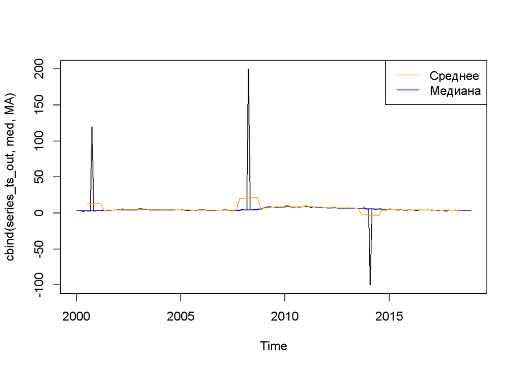

```r
filt <- c(1/24, rep(1/12, 11), 1/24)
MA<-filter(series_ts_out,filt,method="convolution",sides=2)
plot.ts(cbind(series_ts_out,med,MA), plot.type = "single",col=c("black","blue","orange"))
legend("topright", legend = c("Среднее", "Медиана"), col = c("orange","blue"), lty = 1)
```

Видим, что среднее реагируюет на аутлайнеры, а медиана нет.  
Также есть идея использовать сначала скользящую медиану для убирания аутлайнеров, а потом среднее для гладкости функции.

```r
med <- runmed(series_ts, 12)
```

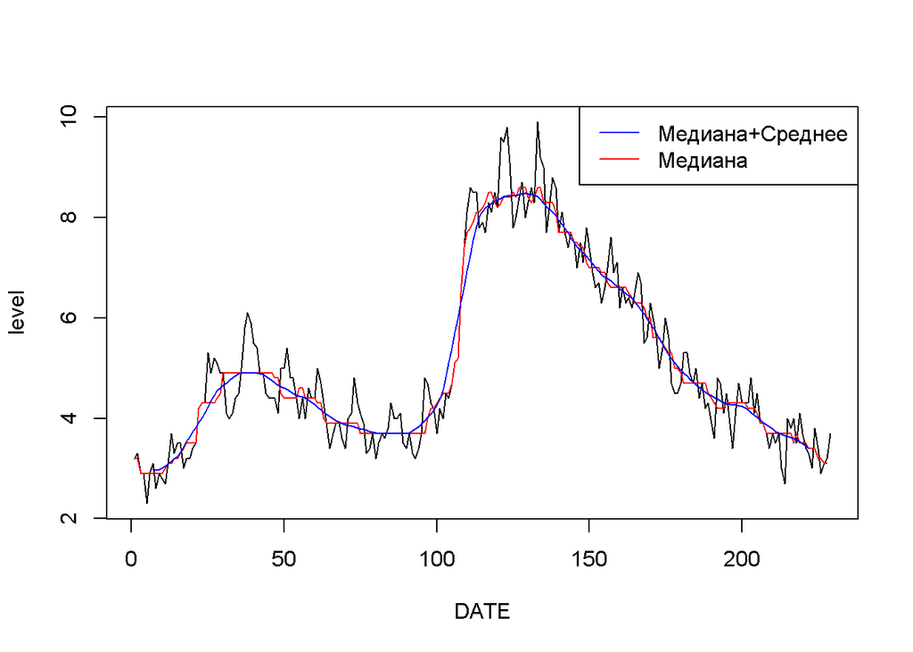

```r
filt <- c(1/24, rep(1/12, 11), 1/24)
MA<-filter(med,filt,method="convolution",sides=2)
plot(series,type="l")
lines(med,col="red")
lines(MA,col="blue")
legend("topright", legend = c("Медиана+Среднее", "Медиана"), col = c("blue","red"), lty = 1)
```